# K-Means Clustering for Patient Segmentation

# Step 5: Model Evaluation and Cluster Analysis

Cluster centers sometimes results in minimal local convergence due to its greedy nature(Ikotun et al.,2023).This step focuses on how the coming clusters are analyzed to assess the quality of clustering of the model. The silhouette score is computed to evaluate how good or standardized each data point is for the actual clusters it belongs to. This score ranges from -1 to 1, where the value indicates how well the clustering boundary is formed, and the higher value of this score shows that the clusters formed are more well-defined. The fviz_silhouette function plots this score of each cluster so we can look for clusters that are far from others. Then, it applies Principal Component Analysis (PCA) to reduce the dimensions and draw clusters in a plane. The fviz_cluster function also shows the clustered points, thus providing details on how data points cluster together.

```
##   cluster size ave.sil.width
## 1       1  299          0.16
## 2       2  237          0.14
## 3       3  489          0.32
```

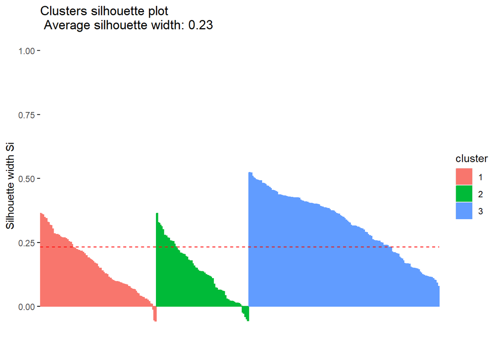

```r
# Calculate silhouette score to evaluate clustering quality
silhouette_score <- silhouette(kmeans_result$cluster, dist(scaled_data))
fviz_silhouette(silhouette_score)
```

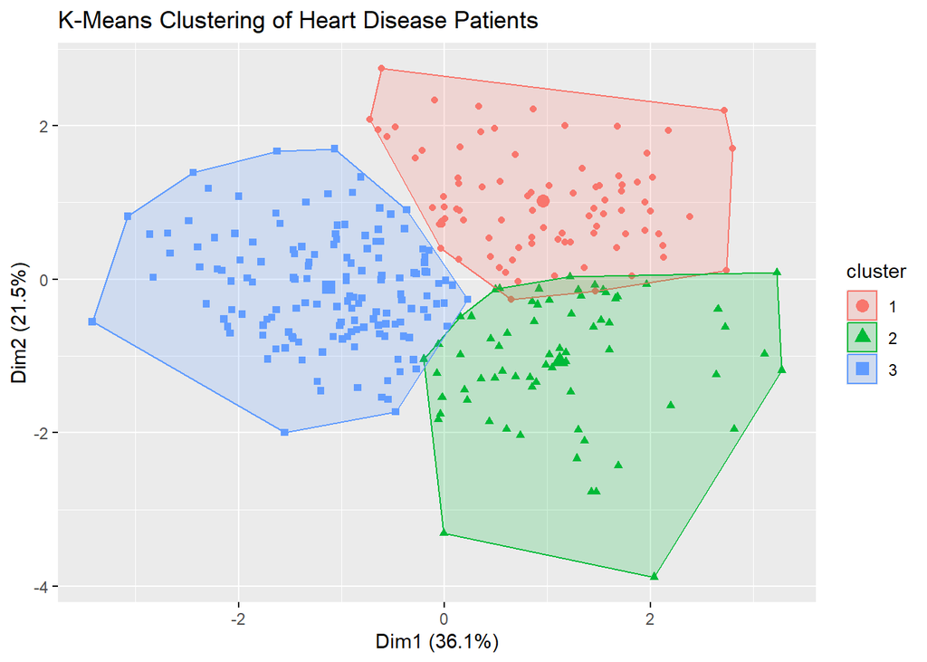

```r
# Visualize clusters using PCA
fviz_cluster(kmeans_result, data = scaled_data, geom = "point") +
  labs(title = "K-Means Clustering of Heart Disease Patients")
```